# Capstone_notebook2 copy 1

Notebook 2 -- What Areas Should the Agency Focus On?

Problem Statement: Should the Department of Housing Preservation and Development of New York City focus on any particular set of boroughs, ZIP codes, or street (where the complaints are severe) for the specific type of complaints you identified in response to Question 1?

```python
# The code was removed by Watson Studio for sharing.
```

```python
client_cred.download_file(Bucket=bucket, Key='df_raw_cos.pkl', Filename='./df_raw_local.pkl')
```

```python
df = pd.read_pickle('./df_raw_local.pkl')
```

```python
#QC of reloading from cloud
df.head()
```

|  | created_date | unique_key | complaint_type | incident_zip | incident_address | street_name | address_type | city | resolution_description | borough | latitude | longitude | closed_date | location_type | status |
| --- | --- | --- | --- | --- | --- | --- | --- | --- | --- | --- | --- | --- | --- | --- | --- |
| 0 | 2020-01-15T21:20:00.000 | 45397440 | HEAT/HOT WATER | 10456.0 | 1250 FRANKLIN AVENUE | FRANKLIN AVENUE | ADDRESS | BRONX | The following complaint conditions are still o... | BRONX | 40.830871 | -73.902850 | NaN | RESIDENTIAL BUILDING | Open |
| 1 | 2020-01-15T10:54:04.000 | 45396490 | GENERAL | 10039.0 | 208 WEST 151 STREET | WEST 151 STREET | ADDRESS | NEW YORK | The following complaint conditions are still o... | MANHATTAN | 40.825551 | -73.936620 | NaN | RESIDENTIAL BUILDING | Open |
| 2 | 2020-01-15T19:45:27.000 | 45397525 | HEAT/HOT WATER | 10039.0 | 247 WEST 145 STREET | WEST 145 STREET | ADDRESS | NEW YORK | The complaint you filed is a duplicate of a co... | MANHATTAN | 40.822237 | -73.940471 | NaN | RESIDENTIAL BUILDING | Open |
| 3 | 2020-01-15T14:51:01.000 | 45396824 | UNSANITARY CONDITION | 11230.0 | 1430 OCEAN AVENUE | OCEAN AVENUE | ADDRESS | BROOKLYN | The following complaint conditions are still o... | BROOKLYN | 40.627188 | -73.956683 | NaN | RESIDENTIAL BUILDING | Open |
| 4 | 2020-01-15T21:36:50.000 | 45399384 | HEAT/HOT WATER | 10467.0 | 3345 DECATUR AVENUE | DECATUR AVENUE | ADDRESS | BRONX | The following complaint conditions are still o... | BRONX | 40.877557 | -73.872945 | NaN | RESIDENTIAL BUILDING | Open |

```python
#Remerging
df['complaint_type'] = np.where(df['complaint_type'] == 'HEATING', 'HEAT/HOT WATER', df['complaint_type'])
```

```python
df['complaint_type'].value_counts()
```

```
HEAT/HOT WATER            2133959
PLUMBING                   710182
GENERAL CONSTRUCTION       500863
UNSANITARY CONDITION       450187
PAINT - PLASTER            361257
PAINT/PLASTER              345866
ELECTRIC                   306871
NONCONST                   260890
DOOR/WINDOW                204666
WATER LEAK                 193057
GENERAL                    150840
FLOORING/STAIRS            137182
APPLIANCE                  112467
HPD Literature Request      52830
SAFETY                      51362
OUTSIDE BUILDING             7124
ELEVATOR                     6700
Unsanitary Condition         5499
CONSTRUCTION                 5078
General                      1163
Safety                        424
STRUCTURAL                     16
Plumbing                       11
AGENCY                          9
VACANT APARTMENT                8
Outside Building                6
Appliance                       4
Electric                        1
Mold                            1
Name: complaint_type, dtype: int64
```

```python
#Reduce to key columns
df_locations = df[['complaint_type', 'borough', 'street_name', 'incident_zip']]
```

```python
#QC of reduction
df_locations.head()
```

|  | complaint_type | borough | street_name | incident_zip |
| --- | --- | --- | --- | --- |
| 0 | HEAT/HOT WATER | BRONX | FRANKLIN AVENUE | 10456.0 |
| 1 | GENERAL | MANHATTAN | WEST 151 STREET | 10039.0 |
| 2 | HEAT/HOT WATER | MANHATTAN | WEST 145 STREET | 10039.0 |
| 3 | UNSANITARY CONDITION | BROOKLYN | OCEAN AVENUE | 11230.0 |
| 4 | HEAT/HOT WATER | BRONX | DECATUR AVENUE | 10467.0 |

```python
#Further reduction to main complaint
df_locations = df_locations[df_locations.complaint_type == 'HEAT/HOT WATER']
```

```python
df_locations.head()
```

|  | complaint_type | borough | street_name | incident_zip |
| --- | --- | --- | --- | --- |
| 0 | HEAT/HOT WATER | BRONX | FRANKLIN AVENUE | 10456.0 |
| 2 | HEAT/HOT WATER | MANHATTAN | WEST 145 STREET | 10039.0 |
| 4 | HEAT/HOT WATER | BRONX | DECATUR AVENUE | 10467.0 |
| 7 | HEAT/HOT WATER | QUEENS | NORTHERN BOULEVARD | 11354.0 |
| 8 | HEAT/HOT WATER | BRONX | TURNBULL AVENUE | 10473.0 |

```python
#Find borough with most complaints
df_locations['borough'].value_counts()
```

```
BRONX            600330
BROOKLYN         570491
MANHATTAN        420009
Unspecified      282917
QUEENS           241986
STATEN ISLAND     18226
Name: borough, dtype: int64
```

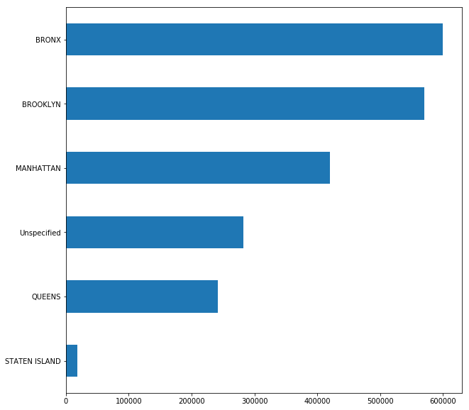

```python
df_locations['borough'].value_counts().sort_values(ascending = True).plot(kind = 'barh', figsize = (10, 10))
plt.show()
```

Bronx has the most, but it looks like Unspecified could potentially change the ranking order

```python
#Ok,Unspecified might mess things up so this needs to be resolved...
Bronxzlist = (10452.0, 10456.0, 10457.0, 10460.0, 10461.0, 10462.0, 10451.0, 10453.0, 10454.0, 10455.0, 10458.0, 10459.0, 10463.0, 10464.0, 10467.0, 10469.0, 10470.0, 10474.0, 10475.0, 10499.0, 10465.0, 10466.0, 10468.0, 10471.0, 10472.0, 10473.0)
for i in Bronxzlist:
    df_locations.loc[df['incident_zip'] == i, 'borough'] = 'BRONX'

Brooklynzlist = (11201.0, 11206.0, 11207.0, 11208.0, 11209.0, 11202.0, 11203.0, 11204.0, 11205.0, 11210.0, 11211.0, 11212.0, 11213.0, 11218.0, 11219.0, 11220.0, 11221.0, 11222.0, 11223.0, 11224.0, 11225.0, 11214.0, 11215.0, 11216.0, 11217.0, 11226.0, 11228.0, 11229.0, 11230.0, 11235.0, 11236.0, 11237.0, 11238.0, 11245.0, 11247.0, 11249.0, 11256.0, 11231.0, 11232.0, 11233.0, 11234.0, 11239.0, 11241.0, 11242.0, 11243.0, 11251.0, 11252.0)
for i in Brooklynzlist:
    df_locations.loc[df['incident_zip'] == i, 'borough'] = 'BROOKLYN'

df_locations['borough'].value_counts()
```

```
BRONX            693160
BROOKLYN         663856
MANHATTAN        416280
QUEENS           241986
Unspecified      100451
STATEN ISLAND     18226
Name: borough, dtype: int64
```

So, there are still ~100k Unspecified, but I know these will get distributed to the remaining boroughs so it's safe to say the Bronx has the most complaints...

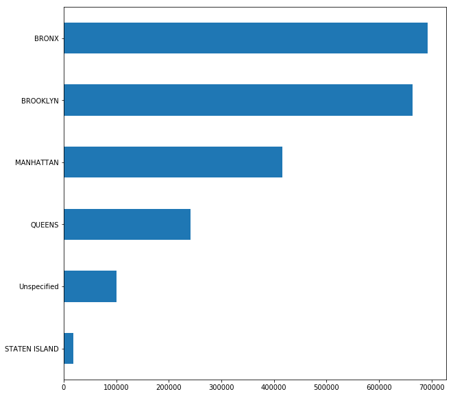

```python
df_locations['borough'].value_counts().sort_values(ascending = True).plot(kind = 'barh', figsize = (10, 10))
plt.show()
```

```python
#So... what's the worst street?
df_locations['street_name'].value_counts()
```

```
GRAND CONCOURSE             37587
BROADWAY                    24379
OCEAN AVENUE                18571
MORRIS AVENUE               16319
ARDEN STREET                15946
ST NICHOLAS AVENUE          15540
AMSTERDAM AVENUE            12219
ELMHURST AVENUE             12186
BOYNTON AVENUE              11094
DR M L KING JR BOULEVARD    10345
OCEAN PARKWAY               10304
WALTON AVENUE                9934
BAILEY AVENUE                9714
LINDEN BOULEVARD             9521
SEDGWICK AVENUE              9494
RIVERSIDE DRIVE              9493
DECATUR AVENUE               9458
CRESTON AVENUE               9240
NOSTRAND AVENUE              9173
SHERMAN AVENUE               8543
EASTERN PARKWAY              7935
BEDFORD AVENUE               7824
3 AVENUE                     7703
SHERIDAN AVENUE              7677
WALLACE AVENUE               7548
2 AVENUE                     7454
DAVIDSON AVENUE              7113
NEW YORK AVENUE              6969
FT WASHINGTON AVENUE         6918
VALENTINE AVENUE             6850
                            ...
ESSEX DRIVE                     1
151 AVE                         1
HA DOOP PLAZA                   1
MARGARET PLACE                  1
FITCHETT STREET                 1
RAVENHURST AVENUE               1
SWEETBROOK ROAD                 1
HONG KONG ST                    1
TIFFANY COURT                   1
89 ST                           1
30 PLACE                        1
RICHARD AVENUE                  1
ST ANDREW PLACE                 1
WEST 8 ST                       1
WARDS ISLAND                    1
BUCHANAN STREET                 1
FRASER STREET                   1
HOLSMAN ROAD                    1
WATERSTONE DRIVE                1
BECKHAM STREET                  1
RHETT AVENUE                    1
HILLSIDE AVE                    1
RIVIERA COURT                   1
OCEAN TERRACE                   1
WINFIELD STREET                 1
DOROTHEA PLACE                  1
OUTERBRIDGE AVENUE              1
SLOSSON AVENUE                  1
AVENUE ST JOHNS                 1
STONE AVENUE                    1
Name: street_name, Length: 6020, dtype: int64
```

Grand Concourse Street has the most complaints

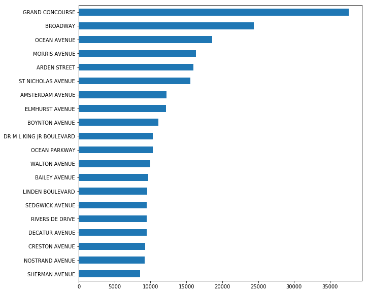

```python
df_locations['street_name'].value_counts().head(20).sort_values(ascending = True).plot(kind = 'barh', figsize = (10, 10))
plt.show()
```

```python
#So... what's the worst zips are in this dataset?
df_locations['incident_zip'].value_counts()
```

```
11226.0    68556
10467.0    65589
10458.0    64930
10468.0    57722
10453.0    57395
10452.0    49431
10457.0    46166
10031.0    44486
10040.0    44317
10456.0    43688
11225.0    42723
11213.0    40127
10462.0    39287
10463.0    37463
10032.0    36202
11212.0    34371
10472.0    33517
10033.0    32892
10460.0    32731
11233.0    30631
11203.0    29142
11221.0    28241
10451.0    26332
11216.0    26300
11207.0    26270
10034.0    26119
10025.0    24691
10466.0    24017
10027.0    23489
11208.0    23444
           ...
11426.0      326
11362.0      313
10309.0      312
11004.0      248
10007.0      227
10006.0      200
10308.0      195
10005.0      181
10307.0      176
10004.0      158
10282.0      155
11001.0      121
10280.0       72
11697.0       66
11040.0       57
10069.0       23
11109.0       23
11005.0        8
10162.0        5
10803.0        4
10041.0        3
10020.0        3
11430.0        2
10169.0        2
10045.0        1
10103.0        1
10129.0        1
10121.0        1
10112.0        1
12345.0        1
Name: incident_zip, Length: 193, dtype: int64
```

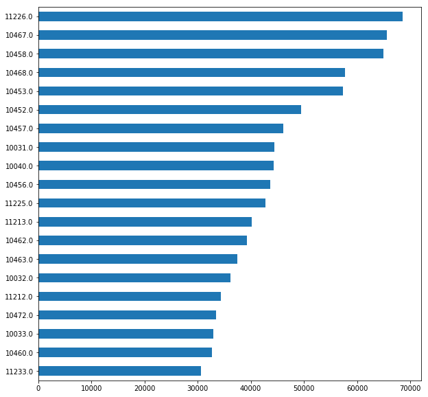

```python
df_locations['incident_zip'].value_counts().head(20).sort_values(ascending = True).plot(kind = 'barh', figsize = (10, 10))
plt.show()
```

The Zip code area 11226 similarly has the most complaints

Visualization of random, first 100 complaints

```python
#!pip install folium
import folium
```

```python
#Go back to full dataframe and scrape top 100 complaints
limit = 100
df_random = df.iloc[0:limit, :]
```

```python
map = folium.Map(location=[40.640, -73.956], zoom_start=11)
map
```

[interactive chart not shown]

```python
#instantiate a feature group
complaints = folium.map.FeatureGroup()

#loops through complaint locations
for lat, long in zip(df_random.latitude, df_random.longitude):
    complaints.add_child(
        folium.CircleMarker(
            [lat, long],
            radius = 5,
            color = 'black',
            fill = True,
            fill_opacity = 0.5
        )
    )

map.add_child(complaints)
```

[interactive chart not shown]

# In conclusion:

Should the Department of Housing Preservation and Development of New York City focus on any particular set of boroughs, ZIP codes, or street (where the complaints are severe) for the specific type of complaints you identified in response to Question 1?

The worst locations are the Bronx Borough, Grand Concourse Street, Zip Code location 11226